# BOO 2025 - Example Analysis

Script 4: PCA - Questions

Bärbel Smit

2025-05-15

> In this script, you will perform principal component analysis (PCA) to further explore patterns in the project data.

# 1 Setup

## 1.1 Clean

As before, we perform several setup steps at the start of the script to ensure our work is reproducible and clear.

**Exercise 1: Download the R markdown template, clean your environment, and set the following variables:**

- `root_dir` - project folder
- `cpm_path` - location of the `cpmData` object
- `metadata_path` - location of the `metaData` object

```r
# clean environment
rm(list=ls())
```

```r
# Set variables
root_dir <- "C:/Users/Bärbel Smit/Universiteit Leiden/BOO 2025 - BOO CDS Giulia team - BOO CDS Giulia team/Students/Bärbel/project/barbelsmit_BOO/"
metadata_path <- file.path(root_dir, "output", "metaData_03samp_QC.RData")
cpm_path <- file.path(root_dir, "output", "cpmData_03samp_QC.RData")
```

## 1.2 Packages

Two new packages are introduced in this script:

- `ComplexHeatmap` allows the drawing and annotation of heatmaps in R
- `circlize` allows for the drawing of circular plots, but is also used by `ComplexHeatmap` for colour functions like `colorRamp2()`

**Exercise 2: Load these packages alongside `tidyverse` into your R environment:**

```r
#load packages
library(tidyverse)
library(ComplexHeatmap)
library(circlize)
```

## 1.3 Load data

**Exercise 3: Load the CPM and metadata into your R environment:**

```r
#load data
load(cpm_path)
load(metadata_path)
```

# 2 PCA

## 2.1 Calculate

In high dimensional data (such as this data with around 10,000 genes), principal components (PCs) can be calculated and used to explore patterns. PCs can be thought of as a new axis in the data that captures the most variance possible in the fewest variables. Gives a more hollistic view.

**Exercise 4: Use the `prcomp()` function to calculate PCs of the `cpmData`:**

```r
# store PCAresults as pcs
# rcomp(): Performs PCA (Principal Component Analysis)
#t(cpmData): Transposes the data so that the rows become samples and columns become genes. This is necessary because prcomp() expects rows = observations (samples) and columns = variables (genes).
pcs <- prcomp(t(cpmData))
```

Tolerance (or `tol`) can be adjusted to create more or fewer PCs, where a lower tolerance generates a higher number. If this argument is not set, the PCs calculated will capture the full variability of the CPM data.

## 2.2 Variance explained

**Exercise 5: Use the output of `prcomp()` to explore your PCs and calculate the variance in CPM values that they explain:**

**Hint**

Variance explained is the SD squared divided by the sum of the variance for all PCs.

```r
# summary PCs
summary(pcs)
```

```
## Importance of components:
##                              PC1       PC2       PC3       PC4       PC5
## Standard deviation     2671.8113 1737.9983 1.009e+03 941.24763 729.30017
## Proportion of Variance    0.4698    0.1988 6.698e-02   0.05831   0.03501
## Cumulative Proportion     0.4698    0.6686 7.356e-01   0.79393   0.82894
##                              PC6       PC7       PC8       PC9      PC10
## Standard deviation     610.32296 540.91871 497.51952 417.14684 371.41815
## Proportion of Variance   0.02452   0.01926   0.01629   0.01145   0.00908
## Cumulative Proportion    0.85345   0.87271   0.88900   0.90045   0.90953
##                             PC11      PC12      PC13      PC14      PC15
## Standard deviation     351.97709 321.08695 292.26404 276.86648 260.16964
## Proportion of Variance   0.00815   0.00679   0.00562   0.00505   0.00445
## Cumulative Proportion    0.91769   0.92447   0.93009   0.93514   0.93959
##                             PC16      PC17      PC18      PC19      PC20
## Standard deviation     226.76995 211.93464 199.42975 192.76339 189.71501
## Proportion of Variance   0.00338   0.00296   0.00262   0.00245   0.00237
## Cumulative Proportion    0.94298   0.94593   0.94855   0.95100   0.95337
##                             PC21      PC22      PC23      PC24     PC25
## Standard deviation     182.09788 168.42234 166.60461 163.19164 160.7754
## Proportion of Variance   0.00218   0.00187   0.00183   0.00175   0.0017
## Cumulative Proportion    0.95555   0.95742   0.95924   0.96099   0.9627
##                             PC26      PC27      PC28      PC29     PC30
## Standard deviation     160.25906 147.57128 144.42481 142.08392 140.6929
## Proportion of Variance   0.00169   0.00143   0.00137   0.00133   0.0013
## Cumulative Proportion    0.96439   0.96582   0.96719   0.96852   0.9698
##                             PC31      PC32      PC33      PC34     PC35
## Standard deviation     139.22902 135.74858 134.66025 131.82225 129.2489
## Proportion of Variance   0.00128   0.00121   0.00119   0.00114   0.0011
## Cumulative Proportion    0.97110   0.97231   0.97351   0.97465   0.9758
##                             PC36      PC37      PC38      PC39     PC40
## Standard deviation     128.92989 126.59321 125.04184 124.07494 123.0017
## Proportion of Variance   0.00109   0.00105   0.00103   0.00101   0.0010
## Cumulative Proportion    0.97684   0.97790   0.97893   0.97994   0.9809
##                             PC41      PC42      PC43      PC44      PC45
## Standard deviation     121.02912 119.17504 117.27021 116.32578 116.06845
## Proportion of Variance   0.00096   0.00093   0.00091   0.00089   0.00089
## Cumulative Proportion    0.98190   0.98284   0.98374   0.98463   0.98552
##                             PC46      PC47      PC48      PC49     PC50
## Standard deviation     114.86605 113.52889 112.08643 110.81127 110.4674
## Proportion of Variance   0.00087   0.00085   0.00083   0.00081   0.0008
## Cumulative Proportion    0.98639   0.98723   0.98806   0.98887   0.9897
##                             PC51      PC52      PC53      PC54      PC55
## Standard deviation     108.60703 107.68247 106.82490 106.56726 105.73749
## Proportion of Variance   0.00078   0.00076   0.00075   0.00075   0.00074
## Cumulative Proportion    0.99045   0.99121   0.99196   0.99271   0.99345
##                             PC56     PC57      PC58      PC59      PC60
## Standard deviation     104.72183 103.1007 102.49300 101.65310 100.88886
## Proportion of Variance   0.00072   0.0007   0.00069   0.00068   0.00067
## Cumulative Proportion    0.99417   0.9949   0.99556   0.99624   0.99691
##                             PC61     PC62     PC63    PC64     PC65      PC66
## Standard deviation     100.39781 98.88068 96.44174 95.1478 93.56253 2.314e-12
## Proportion of Variance   0.00066  0.00064  0.00061  0.0006  0.00058 0.000e+00
## Cumulative Proportion    0.99757  0.99822  0.99883  0.9994  1.00000 1.000e+00
```

```r
# Calculate variance explained
var_explained =
  data.frame(PC = 1:nrow(metaData),
             # The standard deviation of each principal component is being squared (pcs$sdev^2)
             # Then normalizes the variance, so it gives the proportion of total variance explained by each PC
             # Rounds to 3 decimal places
             var_explained = round(pcs$sdev^2 / sum(pcs$sdev^2), 3))

# Inspect the output
var_explained
```

| PC | var_explained |
| --- | --- |
| 1 | 0.470 |
| 2 | 0.199 |
| 3 | 0.067 |
| 4 | 0.058 |
| 5 | 0.035 |
| 6 | 0.025 |
| 7 | 0.019 |
| 8 | 0.016 |
| 9 | 0.011 |
| 10 | 0.009 |

[output cut: 56 more lines]

In this case, 66 principal components `pcs`were computed, collectively accounting for all the variability present in the CPM data, as indicated by the cumulative proportion.

## 2.3 Screeplot

A screeplot can be used to visualize how each subsequent PC captures less and less of the total variance in the data.

**Exercise 6: Plot the top 20 calculated PCs against the variance they explain to generate a screeplot:**

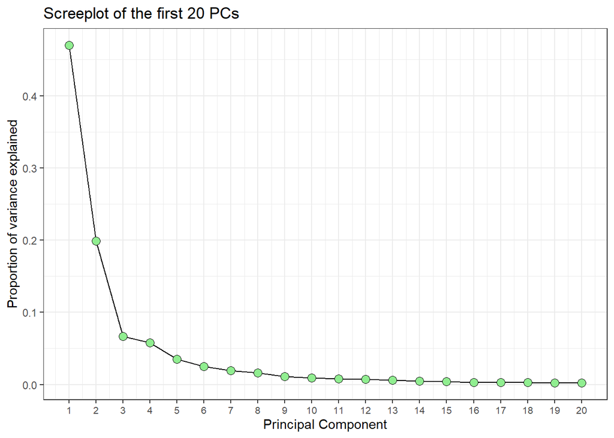

```r
var_explained %>%
  # Filter the data to include only the first 20 principal components
  filter(PC <= 20) %>%
  # Plot PC against variance explained
  ggplot(aes(x = PC, y = var_explained)) +
  # Draw a line between the points
  geom_line(color = "black") +
  # Draw points for each PC
  geom_point(color = "black", fill = 'lightgreen', shape = 21, size = 3) +
  # Label x axis at integer values between 1 and 20
  scale_x_continuous(breaks = c(seq(1,20))) +
  xlab("Principal Component") +
  ylab("Proportion of variance explained") +
  ggtitle("Screeplot of the first 20 PCs") +
  theme_bw() +
  theme(axis.text.x = element_text(size = 8))
```

```r
# See what pcs are above 1%
var_explained %>%
  filter(var_explained > 0.01)
```

| PC | var_explained |
| --- | --- |
| 1 | 0.470 |
| 2 | 0.199 |
| 3 | 0.067 |
| 4 | 0.058 |
| 5 | 0.035 |
| 6 | 0.025 |
| 7 | 0.019 |
| 8 | 0.016 |
| 9 | 0.011 |

You can see that each of the top 9 PCs capture more than 1% of the variation in CPM data so we investigate these further.

## 2.4 Relation to known variables

By investigating how PCs correlate with known variables, we can assess how much each factor impacts expression.

**Exercise 7: Add the PCs that explain more than 1% variance in CPM values to the metaData for further investigation:**

```r
# Add first 9 PCs to metadata
metaData <- cbind(metaData, pcs$x[,1:9])
```

Correlations between known factors and PCs can be calculated using the `cor()` function, which was used for the replicate correlation in the sample QC.

**Exercise 8: Generate a matrix of correlations between PCs explaining over 1% of CPM variance and known factors**

**Hint**

```r
# Applies a column-wise function to metaData, where each column is coerced to a factor (to handle categorical variables), converted to numeric (to assign codes), and then passed to sd(..., na.rm = TRUE) to compute the standard deviation, providing a measure of variability, even for categorical data.
plot_vars <- apply(metaData, 2, function(x) sd(as.numeric(factor(x)), na.rm=T))

# Filter out columns where the SD is NA or 0 (no variation)
plot_vars <- names(plot_vars[!plot_vars %in% c(NA, 0)])

# Remove any variable names containing "PC"
plot_vars <- plot_vars[!grepl("PC", plot_vars)]

# Inspect output
plot_vars
```

```
##  [1] "sample_ID"       "sample_type"     "compound_ID"     "compound_CAS"
##  [5] "compound_name"   "compound_abbr"   "mean_ID"         "mean_ID_control"
##  [9] "control_type"    "conc_ID"         "conc_amt"        "rep"
## [13] "lib_size"        "read_depth"      "plate_ID"        "plate_well"
## [17] "plate_row"       "plate_col"       "batch"           "compound_class"
## [21] "LOAEL_amt"       "PBPK_equivalent" "max_r2"
```

```r
# Creating a new data frame called heatmap_df, by selecting from metaData only the columns listed in plot_vars and using any_of() to include only those that exist
heatmap_df <- metaData %>%
  select(any_of(plot_vars))
```

```r
# Apply a function column-wise (each column = x).
# Convert each column into a factor, then to numeric codes ensuring all variables are numeric, which is needed for correlation.
heatmap_df <- apply(heatmap_df, 2, function(x) as.numeric(factor(x)))

# Calculate the correlation between PCA scores for PCs 1–9 and scaled numeric metadata variables, using pairwise complete observations to handle missing data, and rounds the results to two decimal places
cxy <- round(cor(pcs$x[,1:9], scale(heatmap_df),
                 use = "pairwise.complete.obs"), 2)

# Inspect correlations
as.data.frame(cxy)
```

|  | sample_ID | sample_type | compound_ID | compound_CAS | compound_name | compound_abbr | mean_ID | mean_ID_control | control_type | conc_ID | conc_amt | rep | lib_size | read_depth | plate_ID | plate_well | plate_row | plate_col | batch | compound_class | LOAEL_amt | PBPK_equivalent | max_r2 |
| --- | --- | --- | --- | --- | --- | --- | --- | --- | --- | --- | --- | --- | --- | --- | --- | --- | --- | --- | --- | --- | --- | --- | --- |
| PC1 | 0.27 | -0.37 | 0.21 | 0.38 | -0.12 | -0.27 | 0.31 | -0.36 | -0.72 | -0.20 | 0.45 | 0.01 | 0.13 | 0.13 | -0.17 | 0.21 | 0.19 | 0.07 | 0.38 | -0.38 | -0.38 | 0.38 | -0.16 |
| PC2 | 0.00 | 0.25 | -0.07 | 0.43 | -0.38 | 0.40 | 0.02 | 0.14 | -0.14 | 0.21 | 0.02 | 0.15 | -0.21 | -0.21 | 0.42 | -0.41 | -0.41 | 0.34 | 0.43 | -0.43 | -0.43 | 0.43 | -0.25 |
| PC3 | 0.45 | -0.28 | 0.45 | 0.71 | -0.65 | 0.07 | 0.51 | 0.77 | 0.43 | -0.30 | -0.15 | -0.16 | 0.13 | 0.13 | 0.66 | -0.01 | -0.02 | 0.39 | 0.71 | -0.71 | -0.71 | 0.71 | 0.17 |
| PC4 | -0.38 | 0.26 | -0.29 | 0.05 | -0.05 | 0.25 | -0.37 | 0.33 | 0.37 | -0.13 | -0.60 | -0.02 | 0.08 | 0.07 | 0.04 | -0.36 | -0.39 | 0.06 | 0.05 | -0.05 | -0.05 | 0.05 | 0.25 |
| PC5 | 0.07 | 0.03 | 0.00 | 0.23 | -0.19 | 0.12 | 0.12 | -0.10 | -0.29 | 0.11 | 0.17 | -0.10 | 0.01 | 0.01 | 0.31 | 0.15 | 0.13 | 0.15 | 0.23 | -0.23 | -0.23 | 0.23 | -0.07 |
| PC6 | 0.10 | 0.05 | 0.05 | 0.27 | -0.23 | 0.16 | 0.14 | -0.12 | -0.34 | 0.14 | 0.18 | -0.19 | -0.12 | -0.12 | 0.32 | -0.01 | -0.05 | 0.29 | 0.27 | -0.27 | -0.27 | 0.27 | -0.05 |
| PC7 | -0.13 | 0.03 | -0.03 | -0.12 | 0.10 | -0.02 | -0.16 | 0.34 | 0.50 | -0.15 | -0.33 | -0.37 | 0.30 | 0.30 | -0.20 | -0.02 | -0.02 | -0.12 | -0.12 | 0.12 | 0.12 | -0.12 | 0.30 |
| PC8 | -0.24 | 0.30 | -0.35 | 0.01 | 0.00 | 0.27 | -0.18 | -0.23 | -0.29 | 0.42 | 0.45 | 0.03 | -0.15 | -0.15 | 0.02 | -0.02 | -0.02 | 0.23 | 0.01 | -0.01 | -0.01 | 0.01 | -0.07 |
| PC9 | -0.11 | 0.03 | -0.04 | -0.04 | 0.03 | 0.01 | -0.10 | 0.34 | 0.44 | -0.10 | -0.23 | 0.15 | 0.19 | 0.19 | -0.03 | -0.28 | -0.27 | 0.05 | -0.04 | 0.04 | 0.04 | -0.04 | 0.12 |

Such a correlation matrix can be visualized using a heatmap.

**Exercise 9: Create a heatmap of correlations between known factors and the selected PCs:**

**Hint**

`colorRamp2` can be used to generate a custom colour palette.

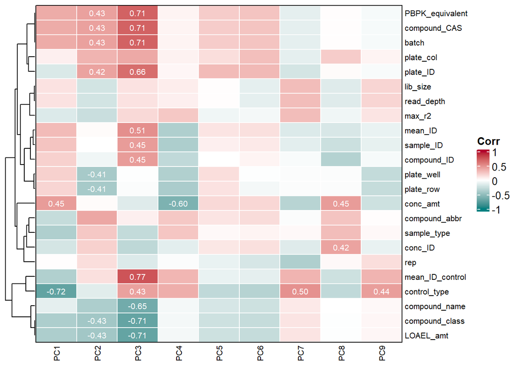

```r
# Make a colour scale from -1 to 1
col_fun <- colorRamp2(c(-1, 0, 1), c("#008080", "white", "#b3002d"))

# Make a heatmap
Heatmap(
  t(cxy),
  # Use col_fun as color palette
  col = col_fun,
  # Add grey border to cells
  border = 'grey5',
  # Clusters the rows (metadata variables) but does not cluster columns (PCs)
  cluster_columns = FALSE,
  show_row_dend = TRUE,
  show_column_dend = FALSE,
  # Set legend name
  name = "Corr",
  # Adjusts font size for row and column names
  row_names_gp = gpar(fontsize = 8),
  column_names_gp = gpar(fontsize = 8),
  cell_fun = function(j, i, x, y, width, height, fill) {
    grid.rect(x, y, width, height,
              gp = gpar(col = "white", lwd = 1, fill = NA))
    # Print correlation if it is above 0.4. The threshold of 0.4 is chosen as a cutoff to highlight only moderately strong correlations inside the heatmap cells
    grid.text(ifelse(abs(t(cxy)[i,j]) > 0.4,
                     sprintf("%.2f", round(t(cxy)[i, j], 2)),
                     ""),
              x, y, gp = gpar(fontsize = 8, col = "white"))
  }
)
```

## 2.5 PCA plot

**Exercise 10: Make a plot of two important PCs against each other, coloured by a relevant factor:**

**Hint**

You can use different shapes to visualize multiple factors in the same plot.

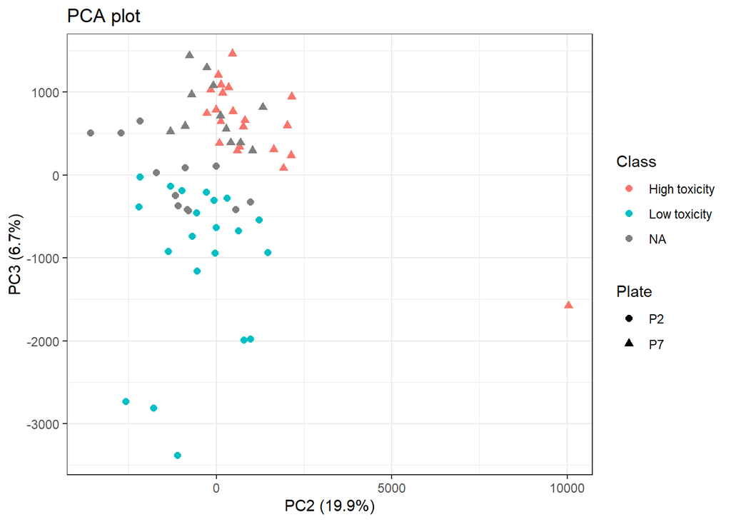

```r
metaData %>%
  # Plot PC2 on x-axis and PC3 on y-axis
  ggplot(aes(x = PC2, y = PC3,
             # Give each compound class a different color and give each plate ID a different shape
             color = compound_class, shape=plate_ID)) +
  geom_point(size = 2) +
  # Add axis labels showing the percentage variance explained by PC2 and PC3 (pulled from var_explained data frame and rounded)
  labs(x = paste0("PC2 (", round(100*var_explained[2,2], 2), "%)"),
       y = paste0("PC3 (", round(100*var_explained[3,2], 2), "%)"),
       color = "Class", shape = "Plate") +
  # Set a title "PCA plot" and use a black-and-white theme
  ggtitle("PCA plot") +
  theme_bw()
```

# 3 Advanced questions

Sometimes a PCA plot can highlight important clusters in your data. Gene loadings can be used to assess which gene’s expression is driving these clusters.

**Exercise 11: Investigate a pattern in your data and identify what genes are responsible for it:**

# 4 Session Info

**Exercise 12: Print your session info at the end of the script, knit the R markdown document, and push it to GitHub:**

```r
# save
save(metaData, file=file.path(root_dir, "output/metaData_04_PCA.RData"))
save(cpmData, file=file.path(root_dir, "output/cpmData_04_PCA.RData"))
```

```r
# session info
library(sessioninfo)
```

[output not shown]

That is the end of the entire QC pipeline. Example answers will be available from the `BOO_template` GitHub on Tuesday.